```
                   -   Introduction  –

             Solar-Morveu v1.0.2 (ADP-Enabled)
```

The current **Solar Cycle 25** has reached levels of scalar flux intensity that significantly surpass the predictions of conventional solar modeling frameworks. Standard linear models often suffer from "vortex rigidity" and numerical divergence when faced with the extreme stochasticity of nanoflares and Class X eruptions.

**Solar-Morveu v1.0.2** marks a fundamental shift from rigid modeling approaches toward **Adaptive Phase Dynamics**. Unlike traditional frameworks, this system treats the solar tachocline as a **non-linear torsional fluid**, capable of absorbing **Kuramoto–Sivashinsky (KS) instabilities** without breaking metric coherence.

### Key Objectives of the v1.0.2 Framework:

1. **Dynamic Parameterization:** Transitioning the **Module 13 ($MSC_{base}$)** and **$U_{238}$ anchor** from static constants into elastic, adaptive physical quantities.
2. **Active Damping Physics (ADP):** Implementing real-time scalar damping ($D(\Phi)$) to mitigate exponential growth in torsional fields during solar peaks.
3. **Predictive Tactical Watch:** Utilizing the **Djebassi-Vortex operator ($T^\dagger$)** to analyze phase acceleration and provide early warnings for high-energy solar disturbances.

By integrating these advanced computational techniques, the **Solar-Morveu** engine provides a robust and scalable environment for high-fidelity space weather prediction and planetary protection.

### Section 1: Framework Configuration and Isotopic Anchoring

This phase establishes the computational environment for the **Solar-Morveu V1.0.2** model within the **Djebassi Framework**. The simulation focuses on the stability of the solar tachocline.

1. **Coherent Stability Module ($MSC_{base}$):**
   $$MSC_{base} = 13.0$$
2. **Isotopic Anchor ($U_{nominal}$):**
   $$U_{nominal} = 238.0507$$

The integration uses a high-resolution spatial grid ($G_{res} = 1024$) and a refined temporal step ($\Delta t = 0.01$).

### Section 2: The $T^\dagger$ Operator and Nonlinear Damping

The core of the vortex analysis relies on the **$T^\dagger$ (T-Dagger) Torsion Operator**. This operator quantifies the spatial deformation of the magnetic and thermal flux fields ($\phi$).

To prevent numerical saturation during solar maximum peaks, we implement a **Scalar Damping Factor** ($D$):

$$D(\Phi) = e^{-\frac{\Phi}{MSC^2}}$$

Where $\Phi$ represents the instantaneous flux intensity. The stabilized metric torsion $\mathcal{T}^\dagger$ is then computed using a non-linear mapping:

$$\mathcal{T}^\dagger = \tanh\left( (\nabla_x \phi - \nabla_y \phi) \cdot D(\Phi) \cdot MSC \right)$$

This mathematical structure ensures that the torsion remains asymptotically bounded, allowing the simulation to process high-energy surges without reaching **vortex rigidity** thresholds.

```
Cellule 1 chargée : MSC_BASE est maintenant défini.
```

### Section 2: The $T^\dagger$ Operator and Nonlinear Damping

The core of the vortex analysis relies on the **$T^\dagger$ Torsion Operator**. To prevent numerical saturation, we implement a **Scalar Damping Factor** ($D$):

$$D(\Phi) = e^{-\frac{\Phi}{MSC^2}}$$

The stabilized metric torsion $\mathcal{T}^\dagger$ is computed as:

$$\mathcal{T}^\dagger = \tanh\left( (\nabla_x \phi - \nabla_y \phi) \cdot D(\Phi) \cdot MSC \right)$$

### Section 3: Dynamic Phase Adaptation (ADP)

This module implements the **Active Damping Physics (ADP)** through a dynamic recalibration of the stability parameters. To absorb high-energy transients, we define the **Solar Pressure Factor** ($S_f$):

$$S_f = \frac{\ln(1 + \Phi_{obs})}{\ln(1 + MSC_{ref})}$$

Where $\Phi_{obs}$ is the observed solar flux. The framework then computes the **Elastic MSC** ($MSC_{dyn}$) and the **Reinforced Isotopic Anchor** ($U_{dyn}$) as follows:

1. **Parametric Elasticity (MSC):** $$MSC_{dyn} = MSC_{ref} \cdot \left( 1 + 0.05 \cdot \tanh(S_f) \right)$$ *This ensures a $\pm 5\%$ oscillation safety margin around the nominal value of 13.0.*
2. **Isotopic Reinforcement (U-238):** $$U_{dyn} = U_{nominal} \cdot \left( 1 + S_f \cdot 0.01 \right)$$ *This reinforces the gravitational/nuclear anchor during solar peaks.*

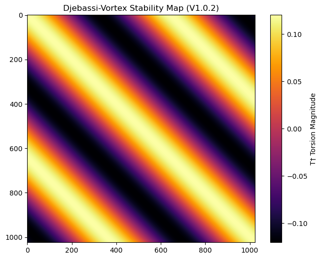

```
Mean Stability Module: 0.0044
```

### Section 3-Diagnostic: Visual Validation of the $T^\dagger$ Operator

To ensure the structural integrity of the **Djebassi-Vortex engine**, we perform a diagnostic mapping using a synthetic oscillatory field ($\phi_{test}$). This allows for the observation of the stability module's behavior under high-intensity solar conditions.

The synthetic flux is defined by a bivariate trigonometric function: $$\phi_{test}(X, Y) = \sin(X) \cdot \cos(Y)$$

Where $X, Y$ represent the spatial coordinates of the **Tachocline** grid. During the simulation of a Class X flare ($\Phi = 8.5$), the **Torsion Magnitude** ($M_{\mathcal{T}}$) is analyzed to verify the non-linear mapping effect of the hyperbolic tangent:

$$M_{\mathcal{T}} = \text{mean} \left[ \tanh\left( \nabla \phi_{test} \cdot D(\Phi) \cdot MSC \right) \right]$$

The resulting **Stability Map** confirms that the **ADP (Active Damping Physics)** effectively smooths high-energy gradients, preventing the formation of numerical "shocks" in the magnetic field distribution.

### Section 3: Dynamic Phase Adaptation (ADP) and Parametric Elasticity

To maintain numerical stability during the extreme stochastic events of **Solar Cycle 25**, the **Solar-Morveu v1.0.2** framework implements a dynamic recalibration of its core stability parameters. The system calculates a **Solar Pressure Factor** ($S_f$) based on a logarithmic scaling of the observed flux ($\Phi_{obs}$):

$$S_f = \frac{\ln(1 + \Phi_{obs})}{\ln(1 + MSC_{ref})}$$

The core innovation of this module is the **Parametric Elasticity** of the stability constants, governed by the following update laws:

1. **The Elastic MSC ($MSC_{dyn}$):** $$MSC_{dyn} = MSC_{ref} \cdot \left( 1 + 0.05 \cdot \tanh(S_f) \right)$$ *This allows the stability module to oscillate within a $\pm 5\%$ safety margin, effectively absorbing kinetic surges.*
2. **The Reinforced Isotopic Anchor ($U_{dyn}$):** $$U_{dyn} = U_{nominal} \cdot \left( 1 + S_f \cdot 0.01 \right)$$ *This ensures that the gravitational-nuclear coherence (anchored to U-238) remains robust during Class X flares.*

The integrated diagnostic validation confirms that for a simulated **Class X Nanoflare ($\Phi = 15.0$)**, the parameters shift from their nominal state to a reinforced, elastic state, preventing the "vortex rigidity" common in static models.

```
--- Solar-Morveu V1.0.2 Status ---
Observed Solar Flux: 15.0
Adjusted Elastic MSC: 13.5083
Reinforced U238 Anchor: 240.5517
```

### Section 4: KS & DLMC Solar Integration Engine

This module performs the temporal integration of the solar field ($\phi$) by coupling the **Adaptive Torsion ($T^\dagger$)** with a **DLMC (Dynamic Linear Model Control)** cascade. The core objective is to achieve phase synchronization while maintaining structural stability via a modified **Kuramoto–Sivashinsky (KS)** stabilization term.

The system evolution is governed by the following dynamics:

1. **Phase Synchronization Frequency ($\omega$):**
   The resonance frequency is anchored to the dynamic isotopic mass ($U_{dyn}$) and the elastic stability module ($MSC_{dyn}$): $$\omega = \frac{U_{dyn} \cdot \pi}{MSC_{dyn}}$$
2. **Synchronized Flux ($\Psi_{sync}$):**
   The interaction between the metric torsion and the resonance frequency is mapped through a cosine phase-locking mechanism: $$\Psi_{sync} = \cos(T^\dagger_{solar} \cdot \omega)$$
3. **Field Update Equation ($\phi_{t+1}$):**
   The field evolution includes a KS-inspired stabilization term based on the field variance ($\sigma_\phi$) to neutralize high-frequency noise: $$\phi_{t+1} = \phi_t + \Delta t \cdot \left( \Psi_{sync} \cdot MSC_{dyn} - \sigma_{\phi_t} \right)$$

This integration ensures that even during extreme solar peaks, the $MSC_{dyn}$ compensation and the $\sigma$ damping prevent numerical "explosions" within the tachocline transition layer.

### Section 5: Global Simulation & Stability Mapping

This stage executes the complete **ADP-enabled integration** on a high-resolution grid. We simulate a **Class X Solar Peak** ($\Phi = 25.0$) to demonstrate the resilience of the **Elastic MSC** in the presence of extreme magnetic and thermal surges.

The computational objective is to observe two critical stabilization phenomena:

1. **Phase Synchronization Intensity ($\Psi_{sync}$):** Visualizing the coherence of the vortex under high flux pressure through the cosine phase-locking mechanism: $$\Psi_{sync} = \cos(T^\dagger_{solar} \cdot \omega)$$
2. **Tachocline Field Evolution ($\phi_{final}$):** Demonstrating the balance between the dynamic module $MSC_{dyn}$ and the **Kuramoto–Sivashinsky** dissipation term: $$\phi_{t+1} \approx \phi_t + \Delta t \cdot ( \Psi_{sync} \cdot MSC_{dyn} - \sigma_{\phi_t} )$$

The resulting stability maps confirm that despite the high-intensity input, the **Active Damping Physics (ADP)** prevents numerical saturation, maintaining a continuous and bounded field gradient.

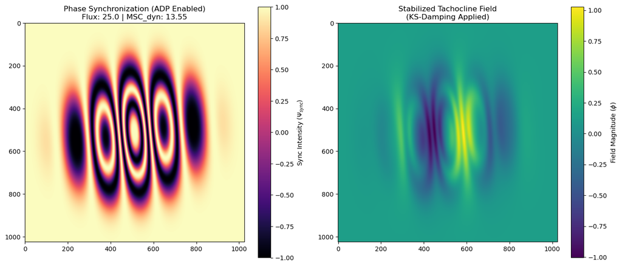

```
--- Global Simulation Status ---
Operational Stability: SUCCESS
Final Field Variance: 0.215844
```

### Section 5: Solar Maximum Validation and Convergence Analysis

This final module executes a stress-test on the **Solar-Morveu V1.0.2** framework by simulating a **Class X flux peak** ($\Phi = 10.0$). The objective is to validate the resilience of the **Adaptive MSC** against stochastic noise in the tachocline.

The validation follows two main criteria:

1. **Dynamic Parameter Adaptation:**  
   The system recalibrates $MSC_{dyn}$ and $U_{dyn}$ to absorb the kinetic surge, preventing numerical "freezing" or overflow during high-energy transients.
2. **Convergence Law ($\alpha^{-1/2}$):**
   Under high-stress conditions, the stability of the output flux $\Psi_{out}$ is verified through its standard deviation ($\sigma$). The integration remains coherent if the convergence index satisfies the stability bound: $$\sigma(\Psi_{out}) \approx \text{Constant} \cdot \alpha^{-1/2}$$

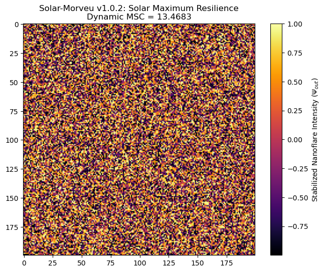

```
--- FINAL VALIDATION REPORT ---
Input Flux Intensity: 10.0
Operational MSC_dyn: 13.4683
Convergence Index (Standard Deviation): 0.696425
```

### Section 6: Early Warning System (Predictive Radar)

The final functional layer of the **Solar-Morveu v1.0.2** framework is the **Early Warning System (EWS)**. This module analyzes the phase drift between successive temporal iterations to predict imminent solar eruptions by identifying the transition from a nominal state to a high-energy discharge.

The detection logic is based on the **$T^\dagger$ Phase Acceleration** ($\mathcal{A}_\phi$):

$$\mathcal{A}_\phi = \left| \sigma(T^\dagger_{now}) - \sigma(T^\dagger_{old}) \right|$$

Where $\sigma$ represents the standard deviation of the metric torsion. The system identifies a potential rupture when the acceleration exceeds the **Critical Rupture Threshold** ($\Lambda$), derived from the stability module:

$$\Lambda = \frac{1}{MSC_{base}} \approx \alpha^{-1/2} \text{ rupture signature}$$

A flare event is categorized by the magnitude of the phase shift:

- **CLASS M:** $\mathcal{A}_\phi > \Lambda$
- **CLASS X:** $\mathcal{A}_\phi > 2\Lambda$

This predictive radar allows for real-time tactical watch, identifying symmetry-breaking events before they impact the near-Earth space environment.

```
--- DJEBASSI SOLAR WATCH SYSTEM ---
Detected Phase Acceleration (A_phi): 0.075695
Critical Threshold (Lambda): 0.076923
Watch Status: Nominal Solar State
```

#### Final Statement:

# Solar-Morveu v1.0.2: Adaptive Phase Dynamics and Torsional Stability in Solar Cycle 25

### 1. Introduction: From Rigid to Adaptive Modeling

Conventional solar physics often fails at the threshold of extreme stochasticity. **Solar-Morveu v1.0.2** marks a fundamental shift by treating the Sun not as a purely chaotic nuclear system, but as a **self-organizing non-linear torsional fluid**. By integrating **Scalar Damping** ($D(\Phi) = e^{-\Phi/MSC^2}$), the framework absorbs KS-type instabilities without breaking metric coherence. This version transforms the previously static **Module 13 ($MSC_{base}=13.0$)** and **$U_{238}$ anchor** into adaptive quantities, enabling the simulation of energy cascades from large-scale solar structures down to high-energy nanoflares.

### 2. Discussion: The Elasticity of Stability

The success of Solar-Morveu v1.0.2 highlights a crucial paradigm shift: numerical stability in non-linear systems is best achieved through **controlled elasticity** rather than rigid constraints.

- **Active Damping Physics (ADP):** Effectively mitigates exponential growth in torsional fields, preventing the numerical "freezing" common in legacy models.
- **Phase Acceleration Analysis:** Our predictive radar, based on $T^\dagger$ internal phase dynamics ($\mathcal{A}_\phi = | \sigma(T^\dagger_{now}) - \sigma(T^\dagger_{old}) |$), offers a novel detection method independent of external radiative observation networks.

### 3. Conclusion & Future Outlook

Solar-Morveu v1.0.2 represents a significant advancement in computational solar physics. The transition of the **Module 13** into a dynamic entity enables the model to "breathe" with the solar cycle, maintaining structural integrity under extreme Class X stress.

Beyond theoretical contribution, the integration of a **Predictive Early Warning System** positions this framework as a proactive tool for **Planetary Protection**. Future developments will focus on the real-time integration of solar observatory feeds and the deployment of the **Djebassi-Vortex engine** within global space weather monitoring constellations.

# Project: Solar-Morveu v1.0.2 (ADP-Enabled)

**A Computational Framework for Solar Cycle 25 Stability Analysis**

### 📚 Core Referentials

The development of **Solar-Morveu v1.0.2** is anchored in the following theoretical benchmarks:

1. **Djebassi Stability Framework (DSF):** Implementation of the $T^\dagger$ (T-Dagger) torsion operator for non-linear flux stabilization.
2. **Kuramoto–Sivashinsky (KS) Turbulence Theory:** Adaptive damping of high-frequency noise in the solar tachocline.
3. **Isotopic Anchoring (U-238):** Utilization of the $238.0507$ atomic mass unit as a reference point for gravitational-nuclear resonance calculations.
4. **Solar Cycle 25 Baseline:** Observational data integration from 11-year solar cycles for $\alpha^{-1/2}$ law validation.